# Expert Elicitation of Directional Metocean Parameters

Lachlan Astfalck

January 16, 2019

This document demonstrates the research presented in Chapter 3 — *“Expert elicitation of directional metocean parameters”*. Already established uses of the SHELF software are not included; rather, the novel methods regarding directional elicitation are presented.

Let us consider the fitting procedure for the Dry season. As presented in the original paper the elicited results are

| Season | $\theta_{\text{mode}}$ | $i = 1$ | $i = 2$ | $i = 3$ | $i = 4$ |
| --- | --- | --- | --- | --- | --- |
| Dry | 225$^\text{o}$ | 0.525 | 0.25 | 0.075 | 0.15 |

for bins $[B_i]$, defined by the conjugate class of $B_i$ such that
$$B_i = \left[
\theta_\text{{mode}} + (i - 1)\frac{360}{k} - \frac{360}{2k},
\theta_\text{{mode}} + (i - 1)\frac{360}{k} + \frac{360}{2k}
\right).$$

This is shown below.

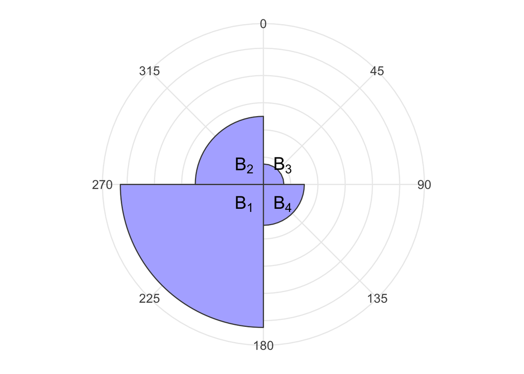

```r
m <- 4

plot_bar <- data.frame(
    dirn = c(45,135,225,315),
    value = c(0.075, 0.15, 0.525, 0.25)
)

plot_text <- data.frame(
    x = c(225,315,45,135),
    y = c(0.10,0.10,0.10,0.10),
    text = sprintf('B[%d]', 1 : 4)
)

ggplot(plot_bar, aes(dirn,value)) +
    geom_col(width = 90, fill = "#b2b2ff", color = "#454545") +
    geom_text(data = plot_text, aes(x, y, label = text), parse = TRUE, size = 6) +
    xlim(0,360) +
    ylim(0,0.525) +
    scale_x_continuous(breaks = seq(0,359,360/8)) +
    coord_polar() +
    theme_bw() +
    theme(
        panel.grid.minor=element_blank(),
        plot.title = element_text(hjust = 0.5),
        axis.text.y = element_blank(),
        axis.ticks.y = element_blank(),
        axis.text.x = element_text(size = 12),
        axis.title.x = element_blank(),
        axis.title.y = element_blank(),
        panel.border = element_blank()
    )
```

Next, we create a number of functions to aid in the fitting process; these are listed as follows.

The function `G0_func` calculates the normalising constant $G_0 = \frac{1}{2\pi}\int^{2\pi}_0 \exp(\kappa_1 \cos(\theta) + \kappa_2 \sin 2(\theta + \frac{\pi}{4})) d\theta$.

```r
G0_func <- function(theta, params){
    return(exp(params[2]*cos(theta) + params[3]*sin(2*(theta+pi/4))))
}
```

`AGvM_func` calculates the pdf of the Asymmetric Generalised von Mises (AGvM) distribution up to the normalising constant such that $f(\theta) \propto \exp(\kappa_1 \cos(\theta - \mu) + \kappa_2 \sin 2(\theta - \mu))$.

```r
AGvM_func <- function(theta, params){
    return(exp(params[2]*cos(theta - params[1]) + params[3]*sin(2*(theta - params[1]))))
}
```

`AGvM_PDF` calculates the pdf of the AGvM distribution such that $f(\theta) = \frac{1}{2\pi G_0(\kappa_1,\kappa_2)}\exp(\kappa_1 \cos(\theta - \mu) + \kappa_2 \sin 2(\theta - \mu))$. The in-built function `integrate` performs an adaptive quadrature scheme to approximate a given function `f` between bounds `lower` and `upper`.

```r
AGvM_PDF <- function(params, theta_loc){
    param_current <- params
    AGvM_likelihood <- vector(length = length(theta_loc))

    G0_int <- integrate(f = G0_func, lower = 0, upper = 2*pi, params = param_current)
    G0 <- G0_int$value/(2*pi)

    AGvM_likelihood <- AGvM_func(theta = theta_loc, params = param_current)/(2*pi*G0)

    return(AGvM_likelihood)
}
```

`AGvM_CDF` evaluates the cdf of the AGvM distribution for a vector of `theta_loc` positions. Again, it utilises the in-built `integrate` function to approximate the integral of `AGvM_PDF` using adaptive quadrature.

```r
AGvM_CDF <- function(params, theta_loc){
    param_current <- params

    AGvM_int <- vector(length = 3)

    G0_int <- integrate(f = G0_func, lower = 0, upper = 2*pi, params = param_current)
    G0 <- G0_int$value/(2*pi)

    for (i in 1:length(theta_loc)){
        int_list <- integrate(f = AGvM_func, lower = 0, upper = theta_loc[i], params = param_current)
        AGvM_int[i] <- int_list$value
    }

    AGvM_CDF_probs <- AGvM_int / (2*pi*G0)
    return(AGvM_CDF_probs)
}
```

Finally, `AGvM_error` computes the squared-sum-residual between the elicited discrete cdf estimates, and the fitted cdf estimates. It is this value that we wish to minimise.

```r
AGvM_error <- function(params, theta_loc, probs){
    param_current <- params
    theta_loc_current <- theta_loc
    SSR <- sum((probs - AGvM_CDF(params = param_current, theta_loc = theta_loc_current))^2)
    return(SSR)
}
```

Now that the required functions have been defined, solve for the set of parameters that fit the elicited values. First, define the bin boundaries, elicited values and modal direction.

```r
elic_theta_loc <- c(pi/2, pi, 3*pi/2)
elic_probs <- c(0.075, 0.225, 0.75)
elic_mode <- 225
season <- "dry"
```

Then we call optimx to find the set of parameter values that minimise `AGvM_error`. We use the Limited-Memory Broyden–Fletcher–Goldfarb–Shanno Box (L-BFGS-B) algorithm so that boundary constraints may be applied to the parameters. We start the optimisation with parameters representing a standard von Mises (vM) distribution centred at the model value with concentration parameter $\kappa = 0.5$. This tends to provide a good starting location for the optimisation algorithm.

```r
    AGvM_optimx = optimx(
        par = c(elic_mode * pi/180,0.5,0),
        fn = AGvM_error,
        lower = c(0, 0, -1),
        upper = c(2*pi, 1000, 1),
        method = "L-BFGS-B",
        theta_loc = elic_theta_loc,
        probs = elic_probs
    )
```

We now compare the theoretical CDF values (`elic_probs`), and the resulting solved CDF values (`solved_probs`) resulting from optimised estimates `optim_params`. It is apparent that the results produce CDF estimates very close to the true values.

```r
    optim_params <- as.vector(coef(AGvM_optimx))

    solved_probs <- AGvM_CDF(params = optim_params, theta_loc = elic_theta_loc)

    print(elic_probs)
```

```
## [1] 0.075 0.225 0.750
```

```r
    print(solved_probs)
```

```
## [1] 0.07499514 0.22499713 0.75000460
```

```r
    print(optim_params)
```

```
## [1]  4.2408202  1.1465300 -0.1148507
```

Finally we graph the pdf of these results below.

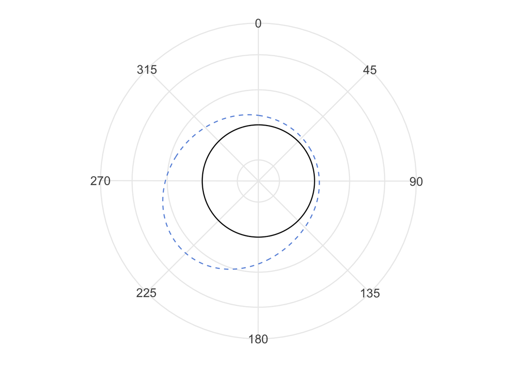

```r
    thetas <- seq(0,2*pi,0.01)
    pdf_values <- AGvM_PDF(params = optim_params, theta_loc = thetas)

    plot_df <- data.frame(
        theta = thetas * 180/pi,
        likelihood = pdf_values * pi/180,
        zeros = 0
    )

    ggplot(plot_df) +
        geom_line(aes(x = theta, y = likelihood), color = "#6893dd", linetype = "dashed") +
        geom_line(aes(x = theta, y = zeros), color = "#000000") +
        scale_x_continuous(breaks = seq(0,360,360/8)) +
        ylim(-0.008,0.012) +
        coord_polar() +
        theme_bw() +
        theme(panel.grid.minor=element_blank(), plot.title = element_text(hjust = 0.5),
            axis.text.y = element_blank(), axis.ticks.y = element_blank(),
            axis.title.x = element_blank(), axis.text.x = element_text(size = 12),
            axis.title.y = element_blank(),panel.border = element_blank())
```